# Chapter 6

# Libraries

```r
library(magrittr)
library(dplyr)
library(plot3D)
library(gam)
library(mgcv)
```

# Simulation 1

- p = 2 and n = 200
- $X_{1}, X_{2}$ iid on [-pi, pi]

Response generated by:

$$Y = cos(X_1) + cos(X_2) + \epsilon$$

## 3D Scatterplot

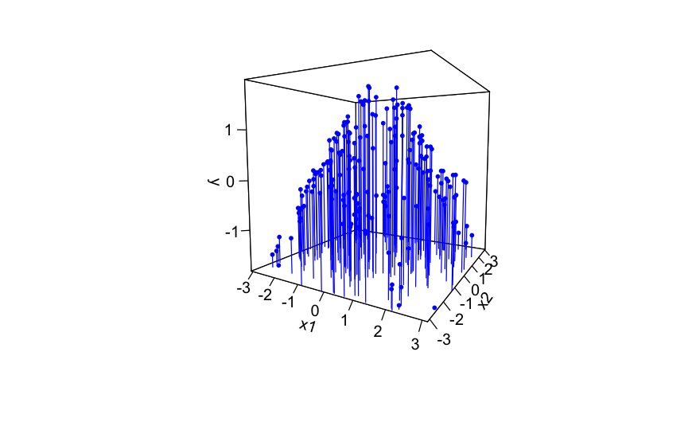

```r
# Simulate a dataset of n=200 observations with p=2 regressors
x1 <- runif(200, min = -pi, max = pi)
x2 <- runif(200, min = -pi, max = pi)
y <- cos(x1) + cos(x2) + rnorm(200, mean = 0, sd = 0.1)
sim <- data.frame(x1, x2, y)

# Construct 3d scatterplot
scatter3D(x1, x2, y, col = "blue", pch = 19, cex = 0.5, type = "h",
          theta = 30, phi = 5, xlab = "x1", ylab = "x2", zlab = "y",
          ticktype = "detailed")
```

## Fitting Additive Model

- s() stands for using spline regression to construct

```r
sim.gam <- gam(y ~ s(x1) + s(x2), data = sim)
```

```
non-list contrasts argument ignored
```

```r
summary(sim.gam)
```

```
Call: gam(formula = y ~ s(x1) + s(x2), data = sim)
Deviance Residuals:
      Min        1Q    Median        3Q       Max
-0.356402 -0.096406  0.001973  0.112515  0.327639

(Dispersion Parameter for gaussian family taken to be 0.0206)

    Null Deviance: 175.903 on 199 degrees of freedom
Residual Deviance: 3.9347 on 190.9996 degrees of freedom
AIC: -198.1192

Number of Local Scoring Iterations: 2

Anova for Parametric Effects
           Df Sum Sq Mean Sq F value    Pr(>F)
s(x1)       1 5.0288  5.0288  244.11 < 2.2e-16 ***
s(x2)       1 0.3634  0.3634   17.64 4.091e-05 ***
Residuals 191 3.9347  0.0206
---
Signif. codes:  0 ‘***’ 0.001 ‘**’ 0.01 ‘*’ 0.05 ‘.’ 0.1 ‘ ’ 1

Anova for Nonparametric Effects
            Npar Df Npar F     Pr(F)
(Intercept)
s(x1)             3 1555.0 < 2.2e-16 ***
s(x2)             3 1472.7 < 2.2e-16 ***
---
Signif. codes:  0 ‘***’ 0.001 ‘**’ 0.01 ‘*’ 0.05 ‘.’ 0.1 ‘ ’ 1
```

```r
sim.gam$coefficients
```

```
(Intercept)       s(x1)       s(x2)
 0.06048794  0.08669680 -0.02429937
```

- Both non linear and linear terms are significant
- Fitted model is hence:

$$\hat{Y} = 0.06 + 0.087X_1-0.02X_2+ \hat{g_1}(X_1) + \hat{g_2}(X_2)$$

## Partial Prediction Plots

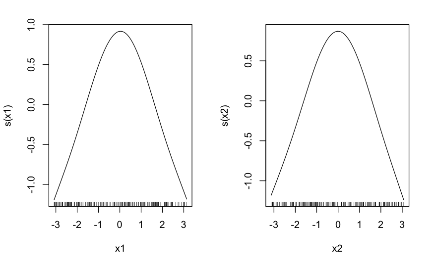

```r
# Construct partial prediction plots
layout(matrix(1:2, c(1,2), byrow = TRUE))
plot(sim.gam)
```

- For first plot, when X2 is fixed, Y and X1 are related in such a way
- For second plot, when X1 is fixed, Y and X2 are related in such a way

## 3D Surface Plots

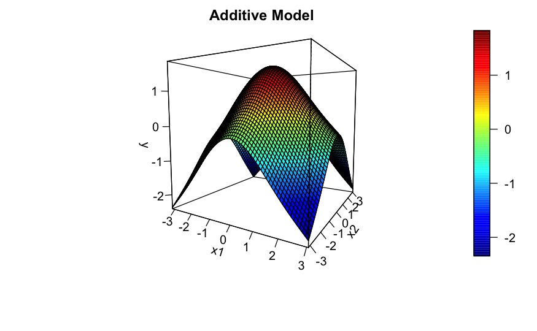

```r
# Create grid matrices for fitted plots
xgrid <- seq(from = -pi, to = pi, by = 0.1)
x1x2grid <- data.frame(expand.grid(x1 = xgrid, x2 = xgrid))
M <- mesh(xgrid, xgrid)

# Construct 3D surface plot of fitted model
pred <- predict(sim.gam, newdata = x1x2grid)
z <- matrix(pred, nrow = length(xgrid))
surf3D(M$x, M$y, z, colvar = z, theta = 30, phi = 5, bty = "f",
       border = "black", xlab = "x1", ylab = "x2", zlab = "y",
       ticktype = "detailed", main="Additive Model")
```

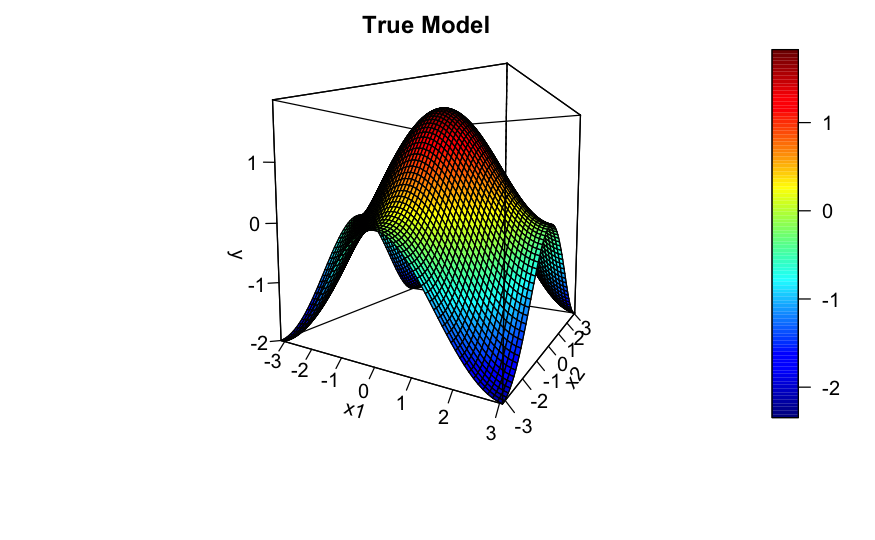

```r
# Construct 3D surface plot of true model
ztrue = cos(M$x) + cos(M$y)
surf3D(M$x, M$y, ztrue, colvar = z, theta = 30, phi = 5, bty = "f",
       border = "black", xlab = "x1", ylab = "x2", zlab = "y",
       ticktype = "detailed", main="True Model")
```

# Simulation 2

- $X_1, X_2, X_3, X_4$ on [-2.5, 2.5]

Component functions:

```r
# Simulate a dataset of n=75 observations with p=4 regressors
x1 <- runif(75, min = -2.5, max = 2.5)
g1 <- -sin(x1)
x2 <- runif(75, min = -2.5, max = 2.5)
g2 <- x2*x2 - 25/12
x3 <- runif(75, min = -2.5, max = 2.5)
g3 <- x3
x4 <- runif(75, min = -2.5, max = 2.5)
g4 <- exp(-x4)-(exp(2.5)-exp(-2.5))/5
y <- g1 + g2 + g3 + g4 + rnorm(75, mean = 0, sd = 1)
sim <- data.frame(x1, x2, x3, x4, y)

# Fit additive model with Gaussian response
sim.gam <- gam(y ~ s(x1) + s(x2) + s(x3) + s(x4), data = sim)
```

```
non-list contrasts argument ignored
```

```r
summary(sim.gam)
```

```
Call: gam(formula = y ~ s(x1) + s(x2) + s(x3) + s(x4), data = sim)
Deviance Residuals:
    Min      1Q  Median      3Q     Max
-1.9766 -0.5291  0.0721  0.5814  1.7299

(Dispersion Parameter for gaussian family taken to be 0.9937)

    Null Deviance: 1163.463 on 74 degrees of freedom
Residual Deviance: 57.6335 on 58 degrees of freedom
AIC: 229.087

Number of Local Scoring Iterations: 2

Anova for Parametric Effects
          Df Sum Sq Mean Sq F value    Pr(>F)
s(x1)      1  81.95   81.95  82.468 9.743e-13 ***
s(x2)      1  10.99   10.99  11.059  0.001534 **
s(x3)      1  91.31   91.31  91.889 1.453e-13 ***
s(x4)      1 414.94  414.94 417.575 < 2.2e-16 ***
Residuals 58  57.63    0.99
---
Signif. codes:  0 ‘***’ 0.001 ‘**’ 0.01 ‘*’ 0.05 ‘.’ 0.1 ‘ ’ 1

Anova for Nonparametric Effects
            Npar Df Npar F   Pr(F)
(Intercept)
s(x1)             3  3.470 0.02174 *
s(x2)             3 89.510 < 2e-16 ***
s(x3)             3  1.653 0.18715
s(x4)             3 59.628 < 2e-16 ***
---
Signif. codes:  0 ‘***’ 0.001 ‘**’ 0.01 ‘*’ 0.05 ‘.’ 0.1 ‘ ’ 1
```

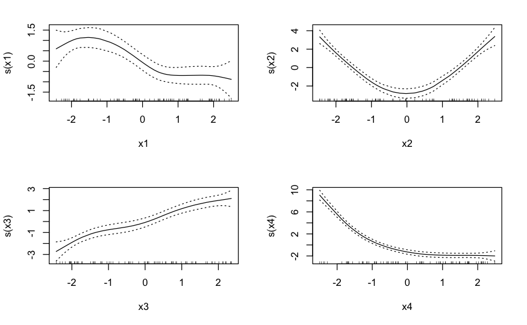

```r
# Construct partial prediction plots
layout(matrix(1:4, c(2,2), byrow = TRUE))
plot(sim.gam, se = TRUE)
```

# Boston Housing Price Data

- Using `mgcv` library
- Does not separate the linear and nonlinear part
- Use this package because solely care about the nonlinear part

```r
# Read Boston Housing Price Data
raw.bhd <-read.csv(file="/Users/jasonchan/MSTAT/STAT6014_Advanced_Stat_Model/Lecture codes/R codes and data for Chapter 6 examples-20200202/BostonHouse.csv", header=TRUE,sep=",")

# Create dataset with log-transformed regressors
bhd <- log(raw.bhd[,1:10])
colnames(bhd) <- paste0("x",1:10)
bhd$medv <- raw.bhd$medv

head(bhd)
```

|  | x1 | x2 | x3 | x4 | x5 | x6 | x7 | x8 | x9 | x10 | medv |
| --- | --- | --- | --- | --- | --- | --- | --- | --- | --- | --- | --- |
| 1 | -5.064036 | 0.8372475 | -0.6198967 | 1.883275 | 4.177459 | 1.408545 | 5.690359 | 2.727853 | 5.983684 | 1.605430 | 24.0 |
| 2 | -3.600502 | 1.9558605 | -0.7571525 | 1.859574 | 4.368181 | 1.602836 | 5.488938 | 2.879198 | 5.983684 | 2.212660 | 21.6 |
| 3 | -3.601235 | 1.9558605 | -0.7571525 | 1.971996 | 4.112512 | 1.602836 | 5.488938 | 2.879198 | 5.973377 | 1.393766 | 34.7 |
| 4 | -3.430523 | 0.7793249 | -0.7808861 | 1.945624 | 3.824284 | 1.802073 | 5.402677 | 2.928524 | 5.977949 | 1.078410 | 33.4 |
| 5 | -2.672924 | 0.7793249 | -0.7808861 | 1.966693 | 3.992681 | 1.802073 | 5.402677 | 2.928524 | 5.983684 | 1.673351 | 36.2 |
| 6 | -3.511570 | 0.7793249 | -0.7808861 | 1.860975 | 4.072440 | 1.802073 | 5.402677 | 2.928524 | 5.976655 | 1.650580 | 28.7 |

## Model 1, All non linear (Full Model)

```r
bhd.gam1 <- gam(medv ~ s(x1) + s(x2) + s(x3) + s(x4) + s(x5)
                + s(x6) + s(x7) + s(x8) + s(x9) + s(x10), data = bhd)
summary(bhd.gam1)
```

```
Family: gaussian
Link function: identity

Formula:
medv ~ s(x1) + s(x2) + s(x3) + s(x4) + s(x5) + s(x6) + s(x7) +
    s(x8) + s(x9) + s(x10)

Parametric coefficients:
            Estimate Std. Error t value Pr(>|t|)
(Intercept)  22.5328     0.1358   165.9   <2e-16 ***
---
Signif. codes:  0 ‘***’ 0.001 ‘**’ 0.01 ‘*’ 0.05 ‘.’ 0.1 ‘ ’ 1

Approximate significance of smooth terms:
         edf Ref.df      F  p-value
s(x1)  3.595  4.569  9.028 6.01e-07 ***
s(x2)  4.810  5.844  3.612   0.0020 **
s(x3)  8.878  8.989 13.458  < 2e-16 ***
s(x4)  8.281  8.855 23.392  < 2e-16 ***
s(x5)  1.770  2.243  0.652   0.4782
s(x6)  7.927  8.702 12.026  < 2e-16 ***
s(x7)  7.504  8.351  8.690 3.10e-11 ***
s(x8)  1.000  1.000 55.987 3.37e-13 ***
s(x9)  1.000  1.000  4.300   0.0387 *
s(x10) 8.093  8.776 28.511  < 2e-16 ***
---
Signif. codes:  0 ‘***’ 0.001 ‘**’ 0.01 ‘*’ 0.05 ‘.’ 0.1 ‘ ’ 1

R-sq.(adj) =   0.89   Deviance explained = 90.1%
GCV =  10.45  Scale est. = 9.3373    n = 506
```

### Partial Plot

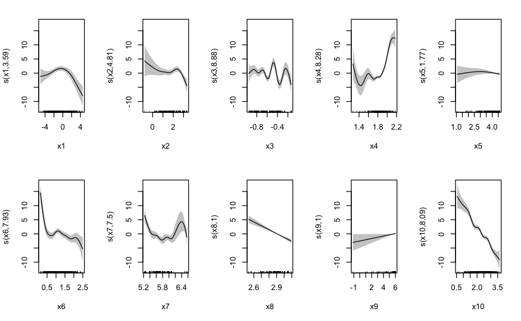

```r
# Construct fit plot for each component
layout(matrix(c(1:10), c(2,5), byrow = TRUE))
plot(bhd.gam1, se = TRUE, shade = TRUE)
```

From the model summary and partial plots, the following improvements were identified:

- Remove x5 due to non significance
- x8 and x9 as linear only

## Model 2, Improved (Reduced Model)

```r
# Fit partial linear additive model with some linear components
bhd.gam2 <- gam(medv ~ s(x1) + s(x2) + s(x3) + s(x4) + s(x6)
                + s(x7) + x8 + x9 + s(x10), data = bhd)

summary(bhd.gam2)
```

```
Family: gaussian
Link function: identity

Formula:
medv ~ s(x1) + s(x2) + s(x3) + s(x4) + s(x6) + s(x7) + x8 + x9 +
    s(x10)

Parametric coefficients:
            Estimate Std. Error t value Pr(>|t|)
(Intercept)  60.3611     5.5091  10.957  < 2e-16 ***
x8          -13.8665     1.8350  -7.557  2.3e-13 ***
x9            0.4338     0.2111   2.055   0.0404 *
---
Signif. codes:  0 ‘***’ 0.001 ‘**’ 0.01 ‘*’ 0.05 ‘.’ 0.1 ‘ ’ 1

Approximate significance of smooth terms:
         edf Ref.df      F  p-value
s(x1)  3.504  4.461  9.033 7.18e-07 ***
s(x2)  4.678  5.703  3.467  0.00312 **
s(x3)  8.854  8.987 13.335  < 2e-16 ***
s(x4)  8.317  8.868 23.642  < 2e-16 ***
s(x6)  7.883  8.681 11.885  < 2e-16 ***
s(x7)  7.728  8.505  8.562 4.02e-11 ***
s(x10) 8.070  8.766 32.887  < 2e-16 ***
---
Signif. codes:  0 ‘***’ 0.001 ‘**’ 0.01 ‘*’ 0.05 ‘.’ 0.1 ‘ ’ 1

R-sq.(adj) =  0.889   Deviance explained = 90.1%
GCV = 10.434  Scale est. = 9.3607    n = 506
```

## Deviance Test

- Compare both model’s deviance

```r
# Compare two models using Deviance test
anova(bhd.gam1, bhd.gam2, test = "Chisq")
```

```
Analysis of Deviance Table

Model 1: medv ~ s(x1) + s(x2) + s(x3) + s(x4) + s(x5) + s(x6) + s(x7) +
    s(x8) + s(x9) + s(x10)
Model 2: medv ~ s(x1) + s(x2) + s(x3) + s(x4) + s(x6) + s(x7) + x8 + x9 +
    s(x10)
  Resid. Df Resid. Dev      Df Deviance Pr(>Chi)
1    446.67     4221.8
2    449.03     4249.4 -2.3573  -27.611   0.2874
```

- Deviance of model 2 is not significantly different from model 1
- Accept model 2 as final model

## Final Model Partial Fit Plot

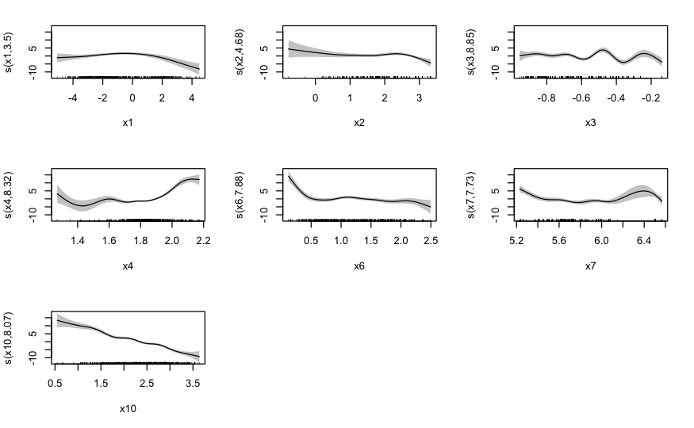

```r
# Construct fit plot for reduced model
plot(bhd.gam2, pages = 1, se = TRUE, shade = TRUE)
```

Final model is then fitted as:

$$\hat{Y} = 60.36 - 13.87X_8 + 0.4338X_9 + \hat{g_1}(X_1)+...$$

where the gs are the non parametric components.

# Mine Fractures Data Revisited

- Past parametric models only assumes that the $log(\mu)$ is linearly related to the predictors
- Appling **GAPLM** allows more flexibility in non linear relationships between $log(\mu)$ and the predictors

```r
mine <- read.csv("/Users/jasonchan/MSTAT/STAT6014_Advanced_Stat_Model/data/mine.csv")

head(mine)
```

|  | y | x1 | x2 | x3 | x4 |
| --- | --- | --- | --- | --- | --- |
| 1 | 2 | 50 | 70 | 52 | 1.0 |
| 2 | 1 | 230 | 65 | 42 | 6.0 |
| 3 | 0 | 125 | 70 | 45 | 1.0 |
| 4 | 4 | 75 | 65 | 68 | 0.5 |
| 5 | 1 | 70 | 65 | 53 | 0.5 |
| 6 | 2 | 65 | 70 | 46 | 3.0 |

## Full Model

- Fit all additive

```r
mine.gam <- gam(y ~ s(x1) + s(x2, k = 9) + s(x3) + s(x4),
                family = poisson, data = mine)
```

- Need to add k = 9 as number of unique values is less than 10, which is the starting number of spline basis

```r
unique(mine$x2)
```

```
[1] 70 65 60 90 80 85 75 50 88
```

### Summary and Partial Plot

```r
summary(mine.gam)
```

```
Family: poisson
Link function: log

Formula:
y ~ s(x1) + s(x2, k = 9) + s(x3) + s(x4)

Parametric coefficients:
            Estimate Std. Error z value Pr(>|z|)
(Intercept)   0.4479     0.1544   2.901  0.00372 **
---
Signif. codes:  0 ‘***’ 0.001 ‘**’ 0.01 ‘*’ 0.05 ‘.’ 0.1 ‘ ’ 1

Approximate significance of smooth terms:
        edf Ref.df Chi.sq  p-value
s(x1) 1.703  2.121  3.242   0.2276
s(x2) 2.363  2.981 22.241 5.68e-05 ***
s(x3) 1.000  1.000  0.034   0.8537
s(x4) 1.000  1.000  3.558   0.0592 .
---
Signif. codes:  0 ‘***’ 0.001 ‘**’ 0.01 ‘*’ 0.05 ‘.’ 0.1 ‘ ’ 1

R-sq.(adj) =  0.571   Deviance explained = 62.3%
UBRE = -0.035818  Scale est. = 1         n = 44
```

- Using `mgcv` package, only concerned about the nonlinear part

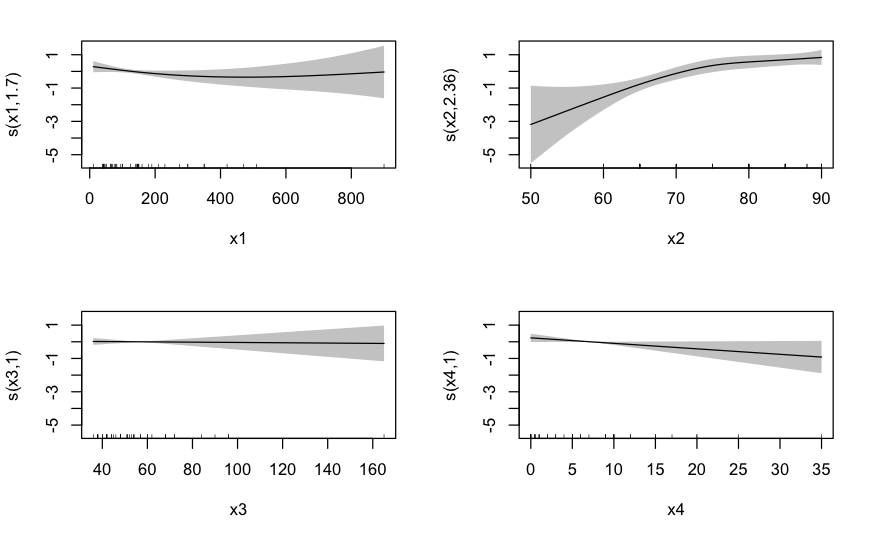

```r
# Construct fit plots for each component
plot(mine.gam, pages = 1, se = TRUE, shade = TRUE)
```

- x1 and x3 are not significant based on summary
- x1 and x2 shows non linear relationships
- x4 shows linear relationship

Hence the following shall be done:

- Remove x1 and x3
- Make x4 linear

## Reduced Model

```r
mine.gam2 <- gam(y ~ s(x2, k = 9) + x4, family = poisson, data = mine)
```

### Summary and Partial Plots

```r
summary(mine.gam2)
```

```
Family: poisson
Link function: log

Formula:
y ~ s(x2, k = 9) + x4

Parametric coefficients:
            Estimate Std. Error z value Pr(>|z|)
(Intercept)  0.66087    0.18247   3.622 0.000293 ***
x4          -0.02979    0.01573  -1.894 0.058228 .
---
Signif. codes:  0 ‘***’ 0.001 ‘**’ 0.01 ‘*’ 0.05 ‘.’ 0.1 ‘ ’ 1

Approximate significance of smooth terms:
       edf Ref.df Chi.sq  p-value
s(x2) 2.69  3.387  21.61 0.000168 ***
---
Signif. codes:  0 ‘***’ 0.001 ‘**’ 0.01 ‘*’ 0.05 ‘.’ 0.1 ‘ ’ 1

R-sq.(adj) =  0.522   Deviance explained = 57.4%
UBRE = -0.060592  Scale est. = 1         n = 44
```

Final model is fitted as:

$$log(\hat{\mu}) = 0.66 - 0.02979X_4+ \hat{g}(X_2)$$

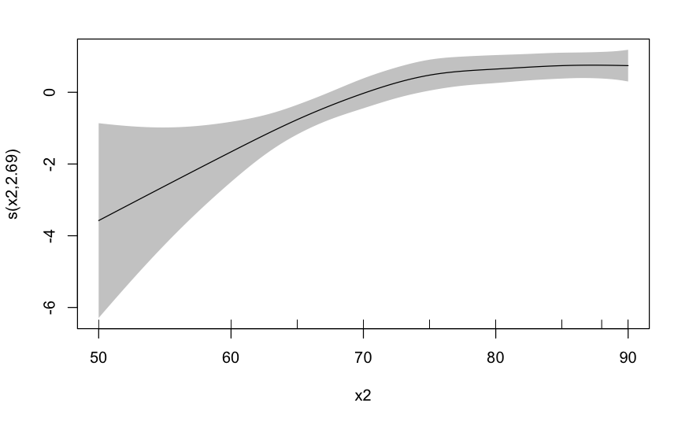

```r
# Construct fit plots for reduced model
plot(mine.gam2, se = TRUE, shade = TRUE)
```

## Deviance Test

```r
# Compare two models using Deviance test
anova(mine.gam, mine.gam2, test = "Chisq")
```

```
Analysis of Deviance Table

Model 1: y ~ s(x1) + s(x2, k = 9) + s(x3) + s(x4)
Model 2: y ~ s(x2, k = 9) + x4
  Resid. Df Resid. Dev      Df Deviance Pr(>Chi)
1    35.898     28.292
2    38.613     31.954 -2.7156  -3.6624   0.2581
```

- Reduced model deviance is not significantly different from full model.